# eight assignment

Simone Travaglini

2023-11-25

Before to start, i loaded the dataset: it contains 5,000 clothing reviews observation. By using the function gsub, i decide to replace apostrophes with an empty space and to delate numbers from the text column

```r
# Load the dataset containing 5,000 clothing reviews
tot <- read.csv("clothing_reviews23.csv")

# Display information about the structure of the dataset
str(tot)

# Replace apostrophes and remove numbers from the 'text' column
tot$text <- gsub("'", " ", tot$text)
tot$text <- gsub("[0-9]+", " ", tot$text)
```

The dataset contains 3 culumns: the first refears to the number of the observation, the second one contains reviews, the last one is a two-level variable: like = 0 or 1.

```r
# Display information about the dataset after preprocessing
str(tot)
```

```
## 'data.frame':    5000 obs. of  3 variables:
##  $ X    : int  1 2 3 4 5 6 7 8 9 10 ...
##  $ text : chr  " Absolutely wonderful - silky and sexy and comfortable" " Love this dress!  it s sooo pretty.  i happened to find it in a store, and i m glad i did bc i never would hav"| __truncated__ "Some major design flaws I had such high hopes for this dress and really wanted it to work for m…
##  $ Liked: int  0 1 0 1 1 0 1 0 1 1 ...
```

Then, i created the corpus for the analysis: after the tokenization, I removed symbols, numbers and so on, created the document feature-matrix and removed words with a term frequency below the threshold = 7 and words with just 1 character.

```r
# Create a corpus from the dataset
myCorpus <- corpus(tot)

# Tokenize the text in the corpus and perform minimal preprocessing
tok2 <- tokens(myCorpus, remove_punct = TRUE, remove_numbers = TRUE, remove_symbols = TRUE, split_hyphens = TRUE, remove_separators = TRUE)
tok2 <- tokens_remove(tok2, stopwords("en"))

# Create a document-feature matrix (DFM) from the tokens
Dfm <- dfm(tok2)

# Trim the DFM by removing words with a term frequency below the threshold (min_termfreq = 3)
Dfm <- dfm_trim(Dfm, min_termfreq = 7, verbose = TRUE)

# Remove words with just 1 character from the DFM
Dfm <- dfm_remove(Dfm, min_nchar = 2)
```

```r
topfeatures(Dfm)
```

```
##  dress   love   size    top    fit  great   like   wear   just fabric
##   2600   2299   1900   1805   1750   1709   1553   1434   1254   1175
```

*APLLYNG GLOVE ALGORITHM VIA QUANTIDA*

Here, I extracted the vocabulary from the dfm and I selected the tokens that are present in our previously corpus…

```r
# Applying the GloVe algorithm via Quanteda

#extract the vocabulary from our Dfm
Dfm_vocab <- featnames(Dfm )
str(Dfm_vocab)

#select the tokens that are present in our previously defined corpus
clothes_tokens <- tokens(myCorpus)
```

… And i matched the two vocabularies.

```r
# Finally, let's match the two vocabularies
clothes_tokens2 <- tokens_select(clothes_tokens, Dfm_vocab, padding = TRUE)
head(clothes_tokens2 )
```

```
## Tokens consisting of 6 documents and 2 docvars.
## text1 :
## [1] "Absolutely"  "wonderful"   ""            "silky"       ""
## [6] "sexy"        ""            "comfortable"
##
## text2 :
##  [1] "Love"     ""         "dress"    ""         ""         ""
##  [7] "sooo"     "pretty"   ""         ""         "happened" ""
## [ ... and 60 more ]
##
## text3 :
##  [1] ""       "major"  "design" "flaws"  ""       ""       ""       "high"
##  [9] "hopes"  ""       ""       "dress"
## [ ... and 103 more ]
##
## text4 :
##  [1] ""         "favorite" "buy"      ""         ""         "love"
##  [7] ""         "love"     ""         "love"     ""         "jumpsuit"
## [ ... and 23 more ]
##
## text5 :
##  [1] "Flattering" "shirt"      ""           "shirt"      ""
##  [6] ""           "flattering" ""           ""           "due"
## [11] ""           ""
## [ ... and 31 more ]
##
## text6 :
##  [1] ""        ""        ""        ""        "petite"  ""        "love"
##  [8] "tracy"   "reese"   "dresses" ""        ""
## [ ... and 99 more ]
```

Then I created a weighted co-occurence matrix. I decided to use the wighted one in order to makes the matrix more easy to treat and less computational heavy. This matrix captures how many times words occur together within a specific context window.

As you can see, features like “absolutelly” and “wonderfull” have a value of 3.75, indicating that they are often used in the same context. A very high value is also 44.46 between “love” and “dress” or 35.66 between “comfortable” and “dress”, indicating that these features are very often used in the same context.

```r
#I create the co-occurence matrix

fcmat_cloth <- fcm(clothes_tokens2, context = "window", count = "weighted", weights = 1/(1:5))
fcmat_cloth
```

```
## Feature co-occurrence matrix of: 2,395 by 2,395 features.
##              features
## features      Absolutely wonderful     silky sexy comfortable     Love
##   Absolutely   0.6666667 3.7500000 0.3333333 0.20   0.3333333 0.500000
##   wonderful    0         0.6666667 0.5000000 0.25   0.6500000 0
##   silky        0         0         0         0.50   0.2500000 0
##   sexy         0         0         0         0.50   2.1666667 0
##   comfortable  0         0         0         0      1.3000000 2.600000
##   Love         0         0         0         0      0         9.333333
##   dress        0         0         0         0      0         0
##   sooo         0         0         0         0      0         0
##   pretty       0         0         0         0      0         0
##   happened     0         0         0         0      0         0
##              features
## features          dress sooo     pretty  happened
##   Absolutely   1.200000 0     0         0
##   wonderful    3.416667 0     0         0
##   silky        0        0     0         0
##   sexy         1.666667 0     0.3333333 0
##   comfortable 35.666667 1.00  2.1666667 0
##   Love        44.466667 0     0         0
##   dress       87.133333 0.25 22.4500000 0.6666667
##   sooo         0        0     1.0000000 0.2500000
##   pretty       0        0     3.8000000 0.5833333
##   happened     0        0     0         0
## [ reached max_feat ... 2,385 more features, reached max_nfeat ... 2,385 more features ]
```

*WORD EMBEDDING VIA GLOVE*

I first estimated our word embedding model using the GlobalVector function. Then, I trained the model by setting the number of iterations to 50 and convergence_tol = 0.01.

```r
#glove function:
glove <- GlobalVectors$new(rank=100, x_max=10)

#model training:
set.seed(123)
system.time(glove_main <- glove$fit_transform(fcmat_cloth, n_iter = 50, convergence_tol = 0.01, n_threads = 1))
```

I don’t know why, but even though I set convergence_tol = 0.01 it continued even after reaching the value.(last iteration was: INFO [12:42:08.506] epoch 50, loss 0.0055)

Given that our model creates two matrices of word-vectors (one referring to the target and one referring to the context), I decided to take the sum of the two, as it could lead to higher quality embeddings:

```r
#context vector
wv_context <- glove$components
#target vector
glove_main

#sum of the two
glove_main2 <- glove_main + t(wv_context)
```

```r
str(glove_main2)
```

```
##  num [1:2395, 1:100] -0.0994 0.2691 0.3098 -0.1806 0.8116 ...
##  - attr(*, "dimnames")=List of 2
##   ..$ : chr [1:2395] "Absolutely" "wonderful" "silky" "sexy" ...
##   ..$ : NULL
```

*PLOT THE RESULTS*

```r
# Let's create a dataframe out of the Glove results
glove_dataframe <- as.data.frame(glove_main2)

#same number of words:
nrow(glove_dataframe)#2395
nrow(fcmat_cloth)#2395

# let's add to glove_dataframe a column with the list of features
glove_dataframe$word <- row.names(glove_dataframe )
colnames(glove_dataframe )
```

I used this function to show the placement of words on the second and third dimensions:

```r
# let's define a plot function for the second and third dimension
plot_words <- function(words, glove_dataframe){
  # empty plot
  plot(0, 0, xlim=c(-1, 1), ylim=c(-1,1), type="n",
       xlab="Second dimension", ylab="Third dimension")
  for (word in words){
    # extract second and third dimensions
    vector <- as.numeric(glove_dataframe[glove_dataframe$word==word,2:3])
    # add to plot
    text(vector[1], vector[2], labels=word)
  }
}
```

I decided to show the placement of these words:

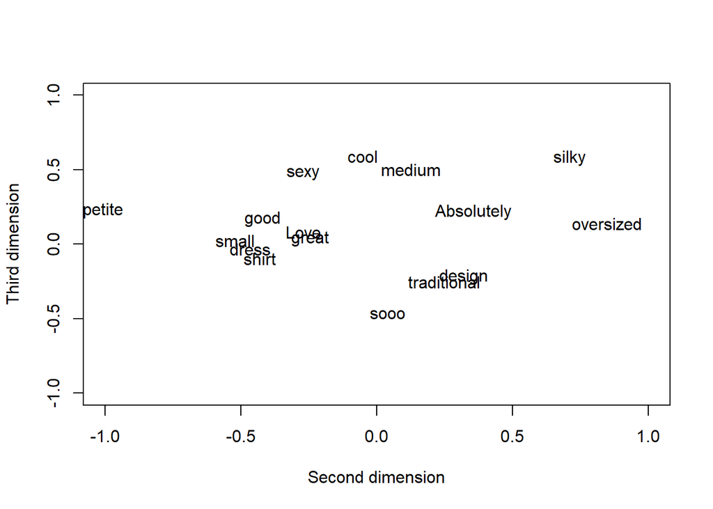

```r
plot_words(c("Absolutely", "design", "silky", "sexy", "Love", "dress", "sooo", "good", "shirt", "great", "cool", "traditional", "medium", "small", "petite", "oversized" ), glove_dataframe)
```

Honestly, I thought petite medium and small were closer in this plot, as well as oversized, being similar words. as I expected, great love and good are very close to each other.

Obviously, it is possible to plot all the dimensions together and show the positioning of the words on the 2D plane. I tried to show the plot of all the words together, but unfortunately it was incomprehensible. I therefore decided to show only the first 500 words. Let’s also see if the previous words are closer in this plot!

```r
set.seed(123)
system.time(tsne <-  Rtsne(glove_main[1:500,], perplexity = 50))
```

```
##    utente   sistema trascorso
##      1.30      0.02      2.07
```

```r
str(tsne)
```

```
## List of 14
##  $ N                  : int 500
##  $ Y                  : num [1:500, 1:2] -2.464 -0.317 1.74 -1.101 -0.423 ...
##  $ costs              : num [1:500] 0.00214 0.00498 0.00215 0.00612 0.00226 ...
##  $ itercosts          : num [1:20] 57.2 58.5 58.2 57.9 58.7 ...
##  $ origD              : int 50
##  $ perplexity         : num 50
##  $ theta              : num 0.5
##  $ max_iter           : num 1000
##  $ stop_lying_iter    : int 250
##  $ mom_switch_iter    : int 250
##  $ momentum           : num 0.5
##  $ final_momentum     : num 0.8
##  $ eta                : num 200
##  $ exaggeration_factor: num 12
##  - attr(*, "class")= chr [1:2] "Rtsne" "list"
```

```r
tsne_plot <- tsne$Y
tsne_plot  <- as.data.frame(tsne_plot)
str(tsne_plot)
```

```
## 'data.frame':    500 obs. of  2 variables:
##  $ V1: num  -2.464 -0.317 1.74 -1.101 -0.423 ...
##  $ V2: num  3.179 -0.986 2.13 -0.15 -3.822 ...
```

```r
tsne_plot$word  <- row.names(glove_main)[1:500]
str(tsne_plot)
```

```
## 'data.frame':    500 obs. of  3 variables:
##  $ V1  : num  -2.464 -0.317 1.74 -1.101 -0.423 ...
##  $ V2  : num  3.179 -0.986 2.13 -0.15 -3.822 ...
##  $ word: chr  "Absolutely" "wonderful" "silky" "sexy" ...
```

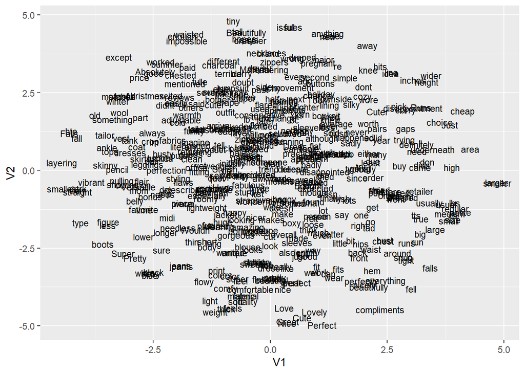

```r
tsne_plot2 <- ggplot(tsne_plot, aes(x = V1, y = V2, label = word)) + geom_text(size = 3)
tsne_plot2
```

Furthermore, using the “which” function, it is possible to see the positioning on the two axes: for example, words “small” and “petite” are really closer in the graph:

```r
tsne_plot[which(tsne_plot$word=="small"),]
```

```
##          V1        V2  word
## 40 3.824122 -1.620499 small
```

```r
tsne_plot[which(tsne_plot$word=="petite"),]
```

```
##         V1        V2   word
## 18 4.07073 -1.334245 petite
```

But also “cute” and “love”:

```r
tsne_plot[which(tsne_plot$word=="Cute"),]
```

```
##            V1        V2 word
## 327 0.6792942 -4.730251 Cute
```

```r
tsne_plot[which(tsne_plot$word=="Love"),]
```

```
##          V1        V2 word
## 6 0.2940206 -4.419888 Love
```

Their proximity in the graph shows the semantic similarity of the two features. After it, I decided to display the embeddings using the umap package. I set the function like this: 1) n_components: 2. 2) nearest neighbours = 20 in order to give more emphasis on local structure. 3) metrics = cosine, because is the appropriate methods for document vectors 4) min_dist = 0.1, because it provides the minimum distance apart that points are allowed to be in the low dimensional representation.

```r
set.seed(123)
system.time(glove_umap <- umap(glove_main, n_components = 2, metric = "cosine", n_neighbors = 20, min_dist = 0.1))
```

then, I plot the partial results (upper right corner):

```r
# Dimensions of end result
glove_umap
head(glove_umap$layout, 3)
df_glove_umap <- as.data.frame(glove_umap$layout)

df_glove_umap$word <- row.names(df_glove_umap)
```

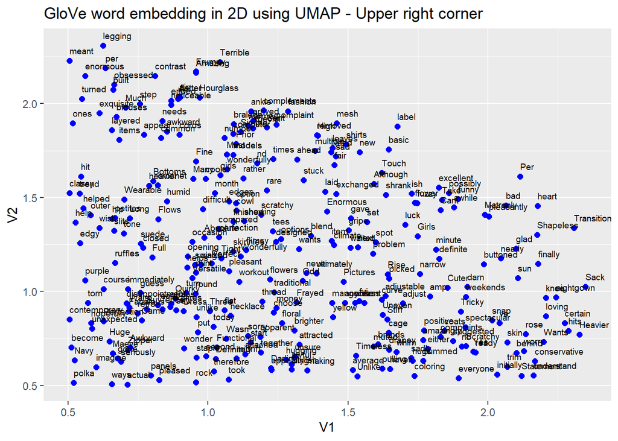

```r
ggplot(df_glove_umap[df_glove_umap$V1 > 0.5 & df_glove_umap$V1 < 3 & df_glove_umap$V2 < 3 & df_glove_umap$V2 > 0.5,]) +
  geom_point(aes(x = V1, y = V2), colour = 'blue', size = 2) +
  geom_text(aes(V1, V2, label =word), size = 2.5, vjust=-1, hjust=0) +
  labs(title = "GloVe word embedding in 2D using UMAP - Upper right corner")
```

I decided to plot the results of the top right corner (first dimension > 0.5, second dimension >0.5). The upper right corner shows the words with the highest value for dimensions 1 and 2

The next step was to see which words were the most similar in terms of similarity: let’s try shopping, Oversized and comfortable (all words relating to clothing)

*COSINE SIMILARITY: SHOPPING*

```r
shopping<- glove_main["shopping", , drop = F]
cos_sim_shopping <- sim2(x = glove_main, y = shopping, method = "cosine", norm = "l2")
head(sort(cos_sim_shopping[,1], decreasing = T), 10)
```

```
##  shopping      mean turquoise  athletic       Get       add     leave      lack
## 1.0000000 0.3639082 0.3035901 0.3013261 0.2825517 0.2800594 0.2664060 0.2626781
##  cleavage    matter
## 0.2595673 0.2550261
```

In terms of cosine similarity, the words with the highest value towards shopping are: mean, turquoise, athletic

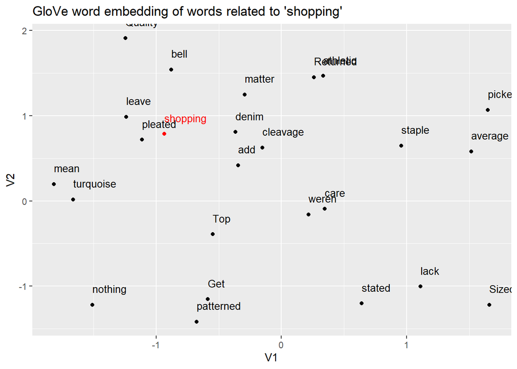

```r
# let's see the results in our UMAP graph
select <- data.frame(rownames(as.data.frame(head(sort(cos_sim_shopping[,1], decreasing = TRUE), 25))))
colnames(select) <- "word"
selected_words <- inner_join(x= df_glove_umap , y=select, by= "word")

ggplot(selected_words, aes(x = V1, y = V2, colour = word == 'shopping')) +
  geom_point(show.legend = FALSE) +
  scale_color_manual(values = c('black', 'red')) +
  geom_text(aes(V1, V2, label = word), show.legend = FALSE, size = 3.5, vjust=-1.5, hjust=0) +
  labs(title = "GloVe word embedding of words related to 'shopping'")
```

*COSINE SIMILARITY: OVERSIZED*

```r
Oversized<- glove_main["Oversized", , drop = F]
cos_sim_Oversized <- sim2(x = glove_main, y = Oversized, method = "cosine", norm = "l2")
head(sort(cos_sim_Oversized[,1], decreasing = T), 10)
```

```
## Oversized   sparkly    bright   mention   sequins   weekend     Solid       Don
## 1.0000000 0.3326349 0.3256006 0.3086269 0.3066447 0.2880804 0.2819011 0.2753734
##     given     solid
## 0.2691687 0.2662266
```

In terms of cosine similarity, the words with the highest value towards oversized are: sparkly, bright, mention

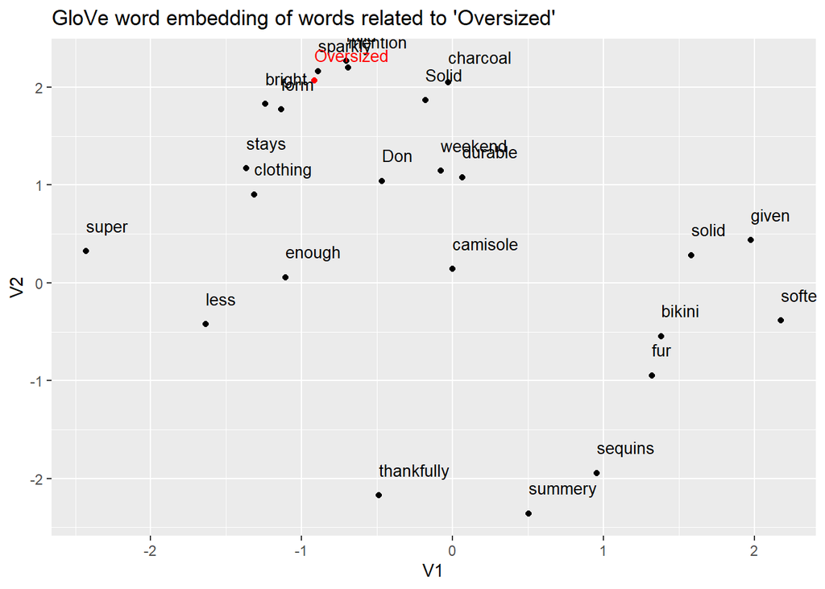

```r
# let's see the results in our UMAP graph
select <- data.frame(rownames(as.data.frame(head(sort(cos_sim_Oversized[,1], decreasing = TRUE), 25))))
colnames(select) <- "word"
selected_words <- inner_join(x= df_glove_umap , y=select, by= "word")

ggplot(selected_words, aes(x = V1, y = V2, colour = word == 'Oversized')) +
  geom_point(show.legend = FALSE) +
  scale_color_manual(values = c('black', 'red')) +
  geom_text(aes(V1, V2, label = word), show.legend = FALSE, size = 3.5, vjust=-1.5, hjust=0) +
  labs(title = "GloVe word embedding of words related to 'Oversized'")
```

*COSINE SIMILARITY: COMFORTABLE*

```r
comfortable<- glove_main["comfortable", , drop = F]
cos_sim_comfortable <- sim2(x = glove_main, y = comfortable, method = "cosine", norm = "l2")
head(sort(cos_sim_comfortable[,1], decreasing = T), 10)
```

```
## comfortable        soft       comfy  flattering         fun         can
##   1.0000000   0.4094746   0.3565630   0.3221562   0.3209576   0.3103050
##        cute      fabric       dress   versatile
##   0.3014175   0.2995722   0.2930187   0.2898758
```

In terms of cosine similarity, the words with the highest value towards comfortable are: soft, comfy, flattering. Compared to the other two words (shopping and oversized), the cosine similarity values are higher

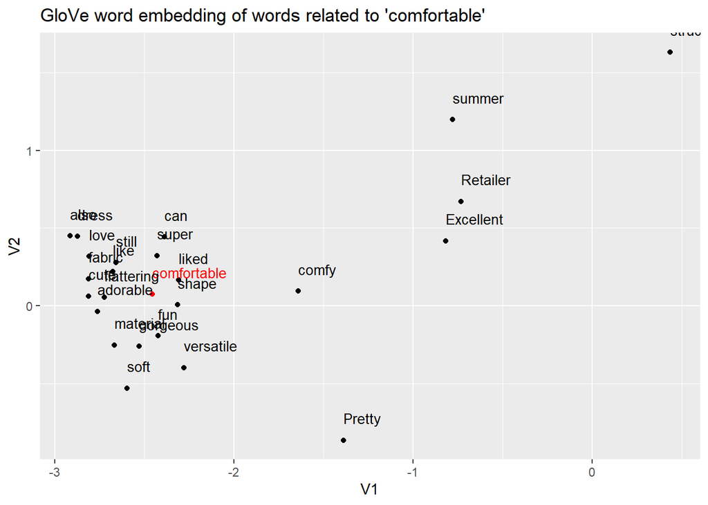

```r
# let's see the results in our UMAP graph
select <- data.frame(rownames(as.data.frame(head(sort(cos_sim_comfortable[,1], decreasing = TRUE), 25))))
colnames(select) <- "word"
selected_words <- inner_join(x= df_glove_umap , y=select, by= "word")

ggplot(selected_words, aes(x = V1, y = V2, colour = word == 'comfortable')) +
  geom_point(show.legend = FALSE) +
  scale_color_manual(values = c('black', 'red')) +
  geom_text(aes(V1, V2, label = word), show.legend = FALSE, size = 3.5, vjust=-1.5, hjust=0) +
  labs(title = "GloVe word embedding of words related to 'comfortable'")
```

Finally, I decided to use the created function similarity to compute the similarity between two words at a time:

```r
similarity <- function(word1, word2){
  lsa::cosine(
    x=as.numeric(glove_dataframe[glove_dataframe$word==word1,1:100]),
    y=as.numeric(glove_dataframe[glove_dataframe$word==word2,1:100]))
}
```

between two similar words:

```r
similarity("great", "nice")
```

```
##           [,1]
## [1,] 0.4846364
```

```r
similarity("big", "large")
```

```
##          [,1]
## [1,] 0.573156
```

In these two cases the words great and nice have a value of 48% according to our similarity function, while big and large have a value of 57%.

…And between two words with opposite meanings:

```r
similarity("cozy", "uncomfortable")
```

```
##            [,1]
## [1,] 0.07167558
```

```r
similarity("traditional", "modern")
```

```
##           [,1]
## [1,] 0.1720685
```

In these two cases the words cozy and uncomfortable have a value of 7% according to our similarity function, while traditional and modern have a value of 17%. Between two opposite words the similarity seems to be very close to 0

…Or between two completely unrelated words:

```r
similarity("winter", "small")
```

```
##            [,1]
## [1,] -0.1383282
```

```r
similarity("summer", "Excellent")
```

```
##            [,1]
## [1,] -0.1326961
```

In these two cases the words winter and small have a value of -13% according to our similarity function, while summer and Excellent have a value of -13%. Between two unconnected words the similarity seems to be negative

*ANALOGIES*

```r
str(glove_main)
```

In this part we see the spatial proximity between vectors, contained into the glove_main matrix. Here I wanted to see which vector was closest to the equation: (vec)winter - (vec)cold + (vec)summer:

```r
ex <- glove_main["winter", , drop = FALSE] -
 glove_main["cold", , drop = FALSE] +
  glove_main["summer", , drop = FALSE]
```

Now let’s see the result:

```r
cos_sim_test <- sim2(x = glove_main, y = ex , method = "cosine", norm = "l2")
head(sort(cos_sim_test[,1], decreasing = T), 5)
```

```
##     summer     winter       fall     spring absolutely
##  0.6929594  0.6164834  0.3685705  0.3251930  0.2921620
```

The result shows that the two most similar words are summer and winter (contained in the equation) but subsequently we have fall, another season less cold than winter.

Here I wanted to see which vector was closest to the equation: (vec)skirt - (vec)woman + (vec)man

```r
ex <- glove_main["skirt", , drop = FALSE] -
 glove_main["woman", , drop = FALSE] +
 glove_main["man", , drop = FALSE]
```

Now let’s see the result:

```r
cos_sim_test <- sim2(x = glove_main, y = ex , method = "cosine", norm = "l2")
head(sort(cos_sim_test[,1], decreasing = T), 5)
```

```
##       man     skirt     drape   wearing     brand
## 0.6593165 0.6254953 0.2988886 0.2800165 0.2763294
```

Result shows that the two most similar words are man and skirt (contained in the equation) but subsequently we have drape, which could refer to the drape suit, a typical male tailored suit.

Here I wanted to see which vector was closest to the equation: (vec)pants - (vec)elegant + (vec)casual

```r
ex <- glove_main["pants", , drop = FALSE] -
 glove_main["elegant", , drop = FALSE] +
 glove_main["casual", , drop = FALSE]
```

Now let’s see the result:

```r
cos_sim_test <- sim2(x = glove_main, y = ex , method = "cosine", norm = "l2")
head(sort(cos_sim_test[,1], decreasing = T), 5)
```

```
##    casual     pants     jeans    skinny     start
## 0.7121155 0.6473031 0.4819763 0.3434871 0.3415967
```

The purpose of this analysis is to see what the most casual version of the classic tailored pants was. The result is jeans, which makes total sense.

*MACHINE LEARNING MODEL*

After this word embedding part, I prepared the dataset by transforming the liked column into a two-level factor, cleaning the text and creating the dfm:

```r
x <- read.csv("clothing_reviews23.csv", stringsAsFactors=FALSE)
str(x)
x$Liked <- factor(x$Liked,  levels=c("0", "1"), labels=c("dontlike", "like"))
# Replace apostrophes and remove numbers from the 'text' column
x$text <- gsub("'", " ", x$text)
x$text <- gsub("[0-9]+", " ", x$text)
# Create a corpus from the dataset
myCorpus <- corpus(x)

# Tokenize the text in the corpus and perform minimal preprocessing
tok2 <- tokens(myCorpus, remove_punct = TRUE, remove_numbers = TRUE, remove_symbols = TRUE, split_hyphens = TRUE, remove_separators = TRUE)
tok2 <- tokens_remove(tok2, stopwords("en"))

# Create a document-feature matrix (DFM) from the tokens
Dfm <- dfm(tok2)

# Trim the DFM  (min_termfreq = 7)
Dfm <- dfm_trim(Dfm, min_termfreq = 7, verbose = TRUE)

# Remove words with just 1 character from the DFM
Dfm <- dfm_remove(Dfm, min_nchar = 2)
```

```r
topfeatures(Dfm, 20)  # 20 top words
```

```
##      dress       love       size        top        fit      great       like
##       2600       2299       1900       1805       1750       1709       1553
##       wear       just     fabric      small      color       cute    perfect
##       1434       1254       1175       1114       1073        995        980
##     really        can  beautiful       look     little flattering
##        929        913        885        884        844        830
```

```r
# our classes
prop.table(table(Dfm@docvars$Liked))
```

```
##
## dontlike     like
##   0.4482   0.5518
```

The proportion is 45% don’t like and 55% like.

I decided to use the support vector machine model: so let’s see what the best configuration could be between the radial and linear models.

I did this: I developed a machine learning model with a word embedding, then a bag of words and compared them. I divided the dataset into two parts: an 80% sample for the training set and a 20% sample for the test set.

*WORD EMBEDDING CROSS VALIDATION with SVM*

```r
# Doing Machine Learning classification with WE

colnames(glove_dataframe )
glove_dataframe <- select(glove_dataframe, word, everything()) # let's move the "word" column to the top
colnames(glove_dataframe )
glove_dataframe[1:5, 2:11]

# dimensions of WE)
nrow(glove_dataframe)
ncol(glove_dataframe)
# but in the original Dfm I had 5000 documents
ndoc(Dfm)


embed <- matrix(NA, nrow=ndoc(Dfm), ncol=100) # empty matrix

for (i in 1:ndoc(Dfm)){
  if (i %% 100 == 0) message(i, '/', ndoc(Dfm))
  # extract word counts
  vec <- as.numeric(Dfm[i,])
  # keep words with counts of 1 or more
  doc_words <- featnames(Dfm)[vec>0]
  # extract embeddings for those words
  embed_vec <- glove_dataframe[glove_dataframe$word %in% doc_words, 2:101]
  # aggregate from word- to document-level embeddings by taking AVG
  embed[i,] <- colMeans(embed_vec, na.rm=TRUE)
  # if no words in embeddings, simply set to 0
  if (nrow(embed_vec)==0) embed[i,] <- 0
}

str(embed)
str(tot)

# 0.4482 0.5518
prop.table(table(tot$Liked))
```

```r
# 1) input
class(embed)
ttt <- as.matrix(embed)
str(ttt)

# 2) dt: name of the empty data-frame in which storing the results of the CV
data2 <- data.frame()
str(data2)

# 3) k: number of k-folds
k <- 5
set.seed(123) # set the see for replicability
folds <- cvFolds(NROW(embed), K=k)
str(folds)

# 4) DV:  name of the DV (it must be a factor!)
class(tot$Liked)
y <- as.factor(tot$Liked)
table(y)
##############
# CV with SVM
##############

source("Function_CV2SVM.R")

# svm with kernel="linear"
SVMlinear_res <- Function_CV2SVM(input=embed, dt=data2, k=5, DV=y, ML=svm, kernel="linear")

# svm with kernel="radial"
SVMradial_res <- Function_CV2SVM(input = embed, data2, 5, y, svm, kernel="radial")
```

```r
colMeans(SVMlinear_res)
```

```
##               Accuracy Avg. Balanced Accuracy                Avg. F1
##              0.7466000              0.7404664              0.7417653
##                   F1 0                   F1 1
##              0.7067633              0.7767674
```

```r
colMeans(SVMradial_res)
```

```
##               Accuracy Avg. Balanced Accuracy                Avg. F1
##              0.7530000              0.7450011              0.7468611
##                   F1 0                   F1 1
##              0.7078399              0.7858823
```

*hyper parameter*

```r
# (let's tune!) the hyperparameters for the SVM

# The main parameter for a SVM linear is C ("cost" - default 1)
hyper_gridSVMl <- expand.grid(
  cost = c(0.1, 1, 5, 10, 15, 20) # hyperparameter values
)

nrow(hyper_gridSVMl) # 4 possibilities by crossing ntree with mtry
hyper_gridSVMl

dt <- data.frame()

Function_CV2SVM

for(j in 1:nrow(hyper_gridSVMl)){
x <- Function_CV2SVM(input=embed, dt=data2, k=5, DV=y, ML=svm, kernel="linear", cost = hyper_gridSVMl$cost[j])
dt[j,1] <- mean(x[ , 1])
dt[j,2] <- mean(x[ , 2])
dt[j,3] <- mean(x[ , 3])
dt[j,4] <- hyper_gridSVMl$cost[j]
colnames(dt)[1] <- "CV_Accuracy"
colnames(dt)[2] <- "CV_Avg. Balanced Accuracy"
colnames(dt)[3] <- "CV_Avg. F1"
colnames(dt)[4] <- "Cost"
}

dt
```

```r
# In this case, any value of C different than the default one (i.e., 1) decreases the performance
SVMlinear_res <- Function_CV2SVM(input=embed, dt=data2, k=5, DV=y, ML=svm, kernel="linear", cost = 10)
```

```
##            Actual
## Predictions   0   1
##           0 303  99
##           1 144 454
##            Actual
## Predictions   0   1
##           0 307 106
##           1 157 430
##            Actual
## Predictions   0   1
##           0 311 132
##           1 138 419
##            Actual
## Predictions   0   1
##           0 306 103
##           1 136 455
##            Actual
## Predictions   0   1
##           0 301 105
##           1 138 456
```

```r
head(arrange(dt, -CV_Accuracy ))
```

```
##   CV_Accuracy CV_Avg. Balanced Accuracy CV_Avg. F1 Cost
## 1      0.7484                 0.7421995  0.7435391 10.0
## 2      0.7470                 0.7408022  0.7421331 15.0
## 3      0.7468                 0.7406818  0.7419843  5.0
## 4      0.7466                 0.7404664  0.7417653  1.0
## 5      0.7460                 0.7396596  0.7410085 20.0
## 6      0.7454                 0.7391837  0.7404982  0.1
```

```r
colMeans(SVMlinear_res [ , c(1, 2, 3)])
```

```
##               Accuracy Avg. Balanced Accuracy                Avg. F1
##              0.7484000              0.7421995              0.7435391
```

The best configuration for the linear model is cost= 10. now let’s do the grid search for the radial model:

```r
# Default value for gamma is: 1/(data dimension), in our case: #gamma refers to non linearity
1/ncol(embed)

hyper_gridSVMr <- expand.grid(
  cost = c(0.1, 1, 5, 10), # hyperparameter values
   gamma = c(0.001, 0.01, 1) # hyperparameter valu
)

nrow(hyper_gridSVMr )
hyper_gridSVMr

dt <- data.frame()

for(j in 1:nrow(hyper_gridSVMr)){
x <- Function_CV2SVM(input=embed, dt=data2, k=5, DV=y, ML=svm, kernel="radial", cost = hyper_gridSVMr$cost[j], gamma = hyper_gridSVMr$gamma[j])
dt[j,1] <- mean(x[ , 1])
dt[j,2] <- mean(x[ , 2])
dt[j,3] <- mean(x[ , 3])
dt[j,4] <- hyper_gridSVMr$cost[j]
dt[j,5] <- hyper_gridSVMr$gamma[j]
colnames(dt)[1] <- "CV_Accuracy"
colnames(dt)[2] <- "CV_Avg. Balanced Accuracy"
colnames(dt)[3] <- "CV_Avg. F1"
colnames(dt)[4] <- "Cost"
colnames(dt)[5] <- "Gamma"
}

dt
```

```r
SVMradial_res <- Function_CV2SVM(input = embed, data2, 5, y, svm, kernel="radial", cost = 1, gamma = 0.01)
```

```
##            Actual
## Predictions   0   1
##           0 284  92
##           1 163 461
##            Actual
## Predictions   0   1
##           0 308  95
##           1 156 441
##            Actual
## Predictions   0   1
##           0 313 114
##           1 136 437
##            Actual
## Predictions   0   1
##           0 299  99
##           1 143 459
##            Actual
## Predictions   0   1
##           0 293  91
##           1 146 470
```

```r
head(arrange(dt, -CV_Accuracy ))
```

```
##   CV_Accuracy CV_Avg. Balanced Accuracy CV_Avg. F1 Cost Gamma
## 1      0.7530                 0.7450011  0.7468611  1.0 0.010
## 2      0.7498                 0.7431992  0.7446629 10.0 0.001
## 3      0.7474                 0.7407221  0.7421548  5.0 0.001
## 4      0.7456                 0.7385690  0.7399880  1.0 0.001
## 5      0.7378                 0.7269405  0.7287728  0.1 0.001
## 6      0.7270                 0.7140067  0.7153692  0.1 0.010
```

```r
colMeans(SVMradial_res [ , c(1, 2, 3)])
```

```
##               Accuracy Avg. Balanced Accuracy                Avg. F1
##              0.7530000              0.7450011              0.7468611
```

The best configuration here is cost=1 and gamma=0.01 (actually, the default value).

```r
result <- as.data.frame(colMeans(SVMlinear_res [ , c(1, 2, 3)]))
str(result)
result <- cbind(result, as.data.frame(colMeans(SVMradial_res [ , c(1, 2, 3)])))

str(result)
resultT <- as.data.frame(t(result))
str(resultT)
row.names(resultT)[1] = "SVMlinear"
row.names(resultT)[2] = "SVMradial"
str(resultT)
resultT$algorithm <- row.names(resultT)
str(resultT)

df.long <- melt(resultT)
str(df.long)
```

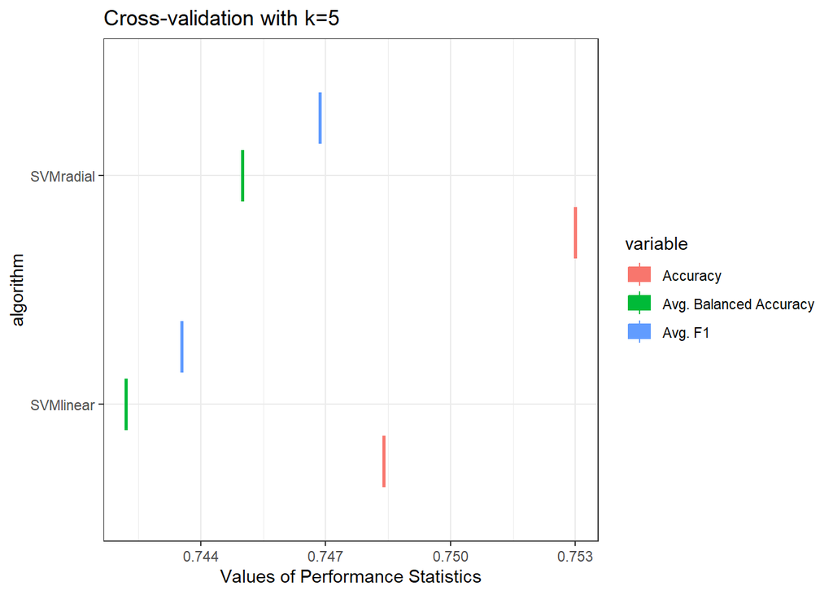

```r
ggplot(df.long,aes(algorithm,value,fill=variable, color = variable))+ geom_boxplot() + coord_flip() +
theme_bw()  + labs(title = "Cross-validation with k=5") + ylab(label="Values of Performance Statistics")
```

```r
head(arrange(resultT, -Accuracy))
```

```
##           Accuracy Avg. Balanced Accuracy   Avg. F1 algorithm
## SVMradial   0.7530              0.7450011 0.7468611 SVMradial
## SVMlinear   0.7484              0.7421995 0.7435391 SVMlinear
```

the best svm model is the radial one. So, let’s set the model in this way: I wanted to divide the data into two parts: the first for the training set (80%) while the second for the test set and predictions (20%)

```r
set.seed(123)  # seed
sample_indices <- sample(1:nrow(embed), 0.8 * nrow(embed))

#training set
embed_train <- embed[sample_indices, ]
y_train <- y[sample_indices]

#test set
embed_test <- embed[-sample_indices, ]
```

let’s estimate the training set:

```r
system.time(SVM_radial <- svm(y = y_train, x = embed_train, kernel = "radial", cost = 1, gamma = 0.01))
```

*RESULTS*

```r
length(SVM_radial$index) #2856
nrow(embed)#5000
```

```r
head(SVM_radial$coefs)
```

```
##            [,1]
## [1,] 1.00000000
## [2,] 1.00000000
## [3,] 0.35571047
## [4,] 0.05789458
## [5,] 0.58177207
## [6,] 0.16929713
```

This output shows the first six values of the coefficient matrix. The coefficients are associated with the support vectors and represent the weight attributed to each support vector. In this case, it appears that the first two support vectors have a weight of 1, while the others have much smaller values. So it means that the first two support vectors are very important.

```r
head(SVM_radial$decision.values)
```

```
##           1/0
## 1 -0.10735709
## 2  0.07930391
## 3  1.34755532
## 4  0.99994417
## 5 -0.91040494
## 6  0.99967132
```

This output shows the first six values of the decision values produced by our SVM model. If the value is positive, the text is classified as the first class (1 = like). If the value is negative, it belongs to the second class (0 = don’t like). in this case therefore the first and fifth cases are “don’t like” the remaining ones are “like”.

However, Looking at the estimated coefficients is not so informative because they only tell us what support vectors were estimated in the model

So, let’s read the texts that represent the support vectors in our case:

```r
tot <- read.csv("clothing_reviews23.csv")
vectors <- tot[SVM_radial$index,]
nrow(vectors)
str(vectors)
vectors$coefs <- SVM_radial$coefs[,1]
str(vectors)
```

```r
# texts about 1 = "liked"
vectors<- vectors[order(vectors$coef),]
str(vectors)
```

```
## 'data.frame':    2856 obs. of  4 variables:
##  $ X    : int  5 8 12 13 14 15 16 17 20 21 ...
##  $ text : chr  "Flattering shirt This shirt is very flattering to all due to the adjustable front tie. it is the perfect length"| __truncated__ "Shimmer, surprisingly goes with lots I ordered this in carbon for store pick up, and had a ton of stuff (as alw"| __truncated__ " This dress is perfecti…
##  $ Liked: int  1 0 1 1 1 0 0 0 1 0 ...
##  $ coefs: num  -1 -1 -1 -1 -1 -1 -1 -1 -1 -1 ...
```

```r
strwrap((vectors$text)[1:5])
```

```
##  [1] "Flattering shirt This shirt is very flattering to all due to the"
##  [2] "adjustable front tie. it is the perfect length to wear with leggings"
##  [3] "and it is sleeveless so it pairs well with any cardigan. love this"
##  [4] "shirt!!!"
##  [5] "Shimmer, surprisingly goes with lots I ordered this in carbon for store"
##  [6] "pick up, and had a ton of stuff (as always) to try on and used this top"
##  [7] "to pair (skirts and pants). everything went with it. the color is"
##  [8] "really nice charcoal with shimmer, and went well with pencil skirts,"
##  [9] "flare pants, etc. my only compaint is it is a bit big, sleeves are long"
## [10] "and it doesn't go in petite. also a bit loose for me, but no xxs... so"
## [11] "i kept it and wil ldecide later since the light color is already sold"
## [12] "out in hte smallest size..."
## [13] "This dress is perfection! so pretty and flattering."
## [14] "Perfect!!! More and more i find myself reliant on the reviews written"
## [15] "by savvy shoppers before me and for the most past, they are right on in"
## [16] "their estimation of the product. in the case of this dress-if it had"
## [17] "not been for the reveiws-i doubt i would have even tried this. the"
## [18] "dress is beautifully made, lined and reminiscent of the old retailer"
## [19] "quality. it is lined in the solid periwinkle-colored fabric that"
## [20] "matches the outer fabric print. tts and very form-fitting. falls just"
## [21] "above the knee and does not rid"
## [22] "Runs big Bought the black xs to go under the larkspur midi dress"
## [23] "because they didn't bother lining the skirt portion (grrrrrrrrrrr). my"
## [24] "stats are 34a-28/29-36 and the xs fit very smoothly around the chest"
## [25] "and was flowy around my lower half, so i would say it's running big."
## [26] "the straps are very pretty and it could easily be nightwear too. i'm"
## [27] "5'6\" and it came to just below my knees."
```

Here we have the ranking of texts with a negative (increasing) coefficient. Given that a negative coefficient is associated with the category 0 = don’t like, these texts are the most important vectors for classification in that category.

```r
# texts about 0 = "don't liked"
vectors <- vectors[order(-vectors$coef),]
str(vectors)
```

```
## 'data.frame':    2856 obs. of  4 variables:
##  $ X    : int  1 2 22 29 33 42 54 60 61 65 ...
##  $ text : chr  " Absolutely wonderful - silky and sexy and comfortable" " Love this dress!  it's sooo pretty.  i happened to find it in a store, and i'm glad i did bc i never would hav"| __truncated__ "I'm torn! I'm upset because for the price of the dress, i thought it was embroidered! no, that …
##  $ Liked: int  0 1 0 1 1 1 1 0 1 1 ...
##  $ coefs: num  1 1 1 1 1 1 1 1 1 1 ...
```

```r
strwrap((vectors$text)[1:5])
```

```
##  [1] "Absolutely wonderful - silky and sexy and comfortable"
##  [2] "Love this dress!  it's sooo pretty.  i happened to find it in a store,"
##  [3] "and i'm glad i did bc i never would have ordered it online bc it's"
##  [4] "petite.  i bought a petite and am 5'8\".  i love the length on me- hits"
##  [5] "just a little below the knee.  would definitely be a true midi on"
##  [6] "someone who is truly petite."
##  [7] "I'm torn! I'm upset because for the price of the dress, i thought it"
##  [8] "was embroidered! no, that is a print on the fabric. i think i cried a"
##  [9] "little when i opened the box. it is still ver pretty. i would say it is"
## [10] "true to size, it is a tad bit big on me, but i am very tiny, but i can"
## [11] "still get away with it. the color is vibrant. the style is unique."
## [12] "skirt portion is pretty poofy. i keep going back and forth on it mainly"
## [13] "because of the price, although the quality is definitely there. except"
## [14] "i wish it were emb"
## [15] "Great shirt!!! I have several of goodhyouman shirts and i get so many"
## [16] "compliments on them. especially the one that says forehead kisses are"
## [17] "underrated. don't hesitate. buy this shirt. you won't be sorry....."
## [18] "Love these pants These pants are even better in person. the only"
## [19] "downside is that they need to be dry cleaned."
```

On the contrary, here we have the ranking of texts with a positive (decreasing) coefficient. Given that a positive coefficient is associated with the category 1 = like, these texts are the most important vectors for classification in that category.

let’s now predict the test set:

```r
predictions <- predict(SVM_radial, newdata = embed_test)

head(predictions)
```

```
## 1 2 3 4 5 6
## 1 1 0 0 0 1
## Levels: 0 1
```

```r
table(predictions )
```

```
## predictions
##   0   1
## 410 590
```

```r
prop.table(table(predictions ))
```

```
## predictions
##    0    1
## 0.41 0.59
```

Predictions show that the first two elements and the sixth belong to class 1, the others to class 0. Furthermore, 41% of the elements belong to class 0, 59 to class 1. The total is 1000 reviews in the test.ì set (20% of our total dataset).

Now let’s try to see the probabilities, adding probability=TRUE to the svm command

```r
system.time(SVMprob <- svm(y = y_train, x = embed_train, kernel = "radial", cost = 1, gamma = 0.01, probability=TRUE))
```

```
##    utente   sistema trascorso
##     14.89      0.02     15.84
```

```r
head(predict(SVMprob , embed_test))
```

```
## 1 2 3 4 5 6
## 1 1 0 0 0 1
## Levels: 0 1
```

```r
head(attr(predict(SVMprob , embed_test,probability=TRUE),"probabilities"))
```

```
##           1         0
## 1 0.8440328 0.1559672
## 2 0.8403864 0.1596136
## 3 0.4022458 0.5977542
## 4 0.2643027 0.7356973
## 5 0.2419432 0.7580568
## 6 0.7436434 0.2563566
```

As before, predictions show that the first two elements (both ~84%) and the sixth (74%) belong to class 1, the others to class 0.

*BAG OF WORDS CROSS VALIDATION with SVM*

As before I make the svm model but without using the word embedding, but simply the dfm transformed into a matrix called ttt. y is the variable “liked”.

```r
ttt <- as(Dfm, "dgCMatrix")

# 2) dt: name of the empty data-frame in which storing the results of the CV
data2 <- data.frame()
str(data2)
```

```
## 'data.frame':    0 obs. of  0 variables
```

```r
k <- 5
set.seed(123) # set the see for replicability
folds <- cvFolds(NROW(ttt), K=k)
str(folds)
```

```
## List of 5
##  $ n      : num 5000
##  $ K      : num 5
##  $ R      : num 1
##  $ subsets: int [1:5000, 1] 2463 2511 2227 526 4291 2986 1842 1142 3371 3446 ...
##  $ which  : int [1:5000] 1 2 3 4 5 1 2 3 4 5 ...
##  - attr(*, "class")= chr "cvFolds"
```

```r
# 4) DV:  name of the DV (it must be a factor!)
class(Dfm@docvars$Liked)
```

```
## [1] "factor"
```

```r
y <- as.factor(Dfm@docvars$Liked)
```

```r
##############
# CV with SVM
##############

source("Function_CV2SVM.R")

# svm with kernel="linear"
SVMlinear_res <- Function_CV2SVM(input=ttt, dt=data2, k=5, DV=y, ML=svm, kernel="linear")

# svm with kernel="radial"
SVMradial_res <- Function_CV2SVM(input = ttt, data2, 5, y, svm, kernel="radial")
```

```r
colMeans(SVMlinear_res)
```

```
##               Accuracy Avg. Balanced Accuracy                Avg. F1
##              0.7348000              0.7284842              0.7296122
##            F1 dontlike                F1 like
##              0.6926293              0.7665952
```

```r
colMeans(SVMradial_res)
```

```
##               Accuracy Avg. Balanced Accuracy                Avg. F1
##              0.6932000              0.6645286              0.6512961
##            F1 dontlike                F1 like
##              0.5304355              0.7721566
```

*hyper parameter*

```r
###################################################
# (let's tune!) the hyperparameters for the SVM
###################################################

colMeans(SVMlinear_res [ , c(1, 2, 3)])

# The main parameter for a SVM linear is C ("cost" - default 1)

hyper_gridSVMl <- expand.grid(
  cost = c(0.1, 1, 5, 10, 15, 20) # hyperparameter values
)

nrow(hyper_gridSVMl)
hyper_gridSVMl

dt <- data.frame()

Function_CV2SVM

for(j in 1:nrow(hyper_gridSVMl)){
x <- Function_CV2SVM(input=ttt, dt=data2, k=5, DV=y, ML=svm, kernel="linear", cost = hyper_gridSVMl$cost[j])
dt[j,1] <- mean(x[ , 1])
dt[j,2] <- mean(x[ , 2])
dt[j,3] <- mean(x[ , 3])
dt[j,4] <- hyper_gridSVMl$cost[j]
colnames(dt)[1] <- "CV_Accuracy"
colnames(dt)[2] <- "CV_Avg. Balanced Accuracy"
colnames(dt)[3] <- "CV_Avg. F1"
colnames(dt)[4] <- "Cost"
}

dt
```

```r
head(arrange(dt, -CV_Accuracy ))

# The best configuration for the linear model is cost= 0.1.
SVMlinear_res <- Function_CV2SVM(input=ttt, dt=data2, k=5, DV=y, ML=svm, kernel="linear", cost = 0.1)
```

The best configuration for the linear model is cost= 0.1. now let’s do the grid search for the radial model:

```r
# Default value for gamma is: 1/(data dimension), in our case: #gamma refers to non linearity
1/ncol(ttt)

hyper_gridSVMr <- expand.grid(
  cost = c(0.1, 1, 5, 10), # hyperparameter values
   gamma = c(0.001, 0.01, 1) # hyperparameter valu
)

nrow(hyper_gridSVMr ) # 12 possibilities
hyper_gridSVMr

dt <- data.frame()

for(j in 1:nrow(hyper_gridSVMr)){
x <- Function_CV2SVM(input=ttt, dt=data2, k=5, DV=y, ML=svm, kernel="radial", cost = hyper_gridSVMr$cost[j], gamma = hyper_gridSVMr$gamma[j])
dt[j,1] <- mean(x[ , 1])
dt[j,2] <- mean(x[ , 2])
dt[j,3] <- mean(x[ , 3])
dt[j,4] <- hyper_gridSVMr$cost[j]
dt[j,5] <- hyper_gridSVMr$gamma[j]
colnames(dt)[1] <- "CV_Accuracy"
colnames(dt)[2] <- "CV_Avg. Balanced Accuracy"
colnames(dt)[3] <- "CV_Avg. F1"
colnames(dt)[4] <- "Cost"
colnames(dt)[5] <- "Gamma"
}

dt
```

```r
head(arrange(dt, -CV_Accuracy ))
```

```
##   CV_Accuracy CV_Avg. Balanced Accuracy CV_Avg. F1 Cost Gamma
## 1      0.7866                 0.7765473  0.7795895    1 0.010
## 2      0.7848                 0.7745035  0.7776038   10 0.001
## 3      0.7816                 0.7702127  0.7733534    5 0.001
## 4      0.7804                 0.7716972  0.7743025    5 0.010
## 5      0.7666                 0.7596034  0.7614201   10 0.010
## 6      0.7458                 0.7280633  0.7290731    1 0.001
```

```r
#The best configuration here is cost=1 and gamma=0.01 (actually, the default value).
SVMradial_res <- Function_CV2SVM(input = ttt, data2, 5, y, svm, kernel="radial", cost = 1, gamma = 0.01)
```

```
##            Actual
## Predictions dontlike like
##    dontlike      292   71
##    like          155  482
##            Actual
## Predictions dontlike like
##    dontlike      318   75
##    like          146  461
##            Actual
## Predictions dontlike like
##    dontlike      304   66
##    like          145  485
##            Actual
## Predictions dontlike like
##    dontlike      317   74
##    like          125  484
##            Actual
## Predictions dontlike like
##    dontlike      293   64
##    like          146  497
```

The best configuration here is cost=1 and gamma=0.01 (actually, the default value).

```r
result <- as.data.frame(colMeans(SVMlinear_res [ , c(1, 2, 3)]))
str(result)
result <- cbind(result, as.data.frame(colMeans(SVMradial_res [ , c(1, 2, 3)])))

str(result)
resultT <- as.data.frame(t(result))
str(resultT)
row.names(resultT)[1] = "SVMlinear"
row.names(resultT)[2] = "SVMradial"
str(resultT)
resultT$algorithm <- row.names(resultT)
str(resultT)

df.long <- melt(resultT)
str(df.long)
```

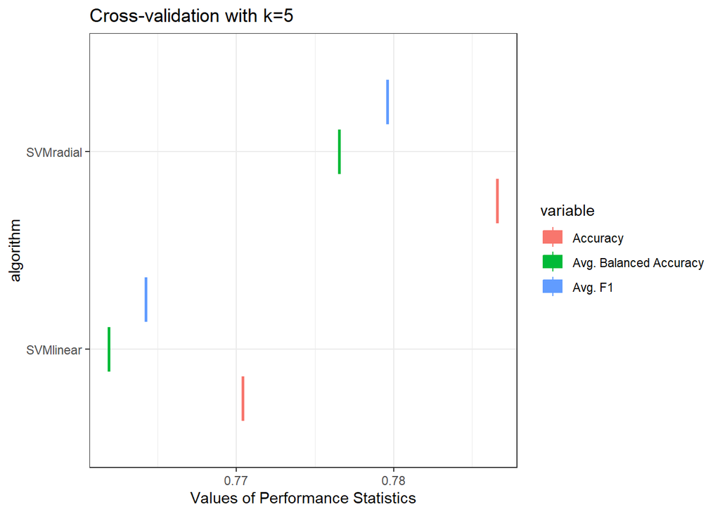

```r
ggplot(df.long,aes(algorithm,value,fill=variable, color = variable))+ geom_boxplot() + coord_flip() +
theme_bw()  + labs(title = "Cross-validation with k=5") + ylab(label="Values of Performance Statistics")
```

```r
head(arrange(resultT, -Accuracy))
```

```
##           Accuracy Avg. Balanced Accuracy   Avg. F1 algorithm
## SVMradial   0.7866              0.7765473 0.7795895 SVMradial
## SVMlinear   0.7704              0.7618844 0.7642533 SVMlinear
```

The best svm model is the radial one, as before. So, let’s set the model in this way: I wanted to divide the data into two parts: the first for the training set (80%) while the second for the test set and predictions (20%)

```r
set.seed(123)  # seed
sample_indices <- sample(1:nrow(ttt), 0.8 * nrow(ttt))

#training set
ttt_train <- ttt[sample_indices, ]
y2_train <- y[sample_indices]

#test set
ttt_test <- ttt[-sample_indices, ]
```

let’s estimate the training set:

```r
system.time(SVM_radial2 <- svm(y = y2_train, x = ttt_train, kernel = "radial", cost = 1, gamma = 0.01))
```

*RESULTS*

```r
length(SVM_radial2$index) #2786
nrow(ttt)#5000
```

```r
head(SVM_radial2$coefs)
```

```
##           [,1]
## [1,] 1.0000000
## [2,] 1.0000000
## [3,] 0.1425618
## [4,] 1.0000000
## [5,] 0.8090083
## [6,] 1.0000000
```

```r
head(SVM_radial2$decision.values)#bag of word
```

```
##   like/dontlike
## 1   -0.68083114
## 2    0.01397668
## 3    0.99975914
## 4    0.82566652
## 5   -1.23448584
## 6    0.99981494
```

```r
head(SVM_radial$decision.values)#word embedding
```

```
##           1/0
## 1 -0.10735709
## 2  0.07930391
## 3  1.34755532
## 4  0.99994417
## 5 -0.91040494
## 6  0.99967132
```

This output shows the first six values of the decision values produced by ours SVM model. If the value is positive, the text is classified as the first class (1 = like). If the value is negative, it belongs to the second class (0 = don’t like). The two models are pretty similar: the first and the fifth have a negative value, others have positive coefficients

However, Looking at the estimated coefficients is not so informative because they only tell us what support vectors were estimated in the model

So, let’s read the texts that represent the support vectors in our case:

```r
tot <- read.csv("clothing_reviews23.csv")
vectors2 <- tot[SVM_radial2$index,]
nrow(vectors2)
str(vectors2)
vectors2$coefs <- SVM_radial2$coefs[,1]
str(vectors2)
```

```r
# texts about 1 = "liked"
vectors2<- vectors2[order(vectors2$coef),]
str(vectors2)
```

```
## 'data.frame':    2785 obs. of  4 variables:
##  $ X    : int  8 12 13 14 16 20 21 24 32 36 ...
##  $ text : chr  "Shimmer, surprisingly goes with lots I ordered this in carbon for store pick up, and had a ton of stuff (as alw"| __truncated__ " This dress is perfection! so pretty and flattering." "Perfect!!! More and more i find myself reliant on the reviews written by savvy shoppers before me…
##  $ Liked: int  0 1 1 1 0 1 0 0 1 0 ...
##  $ coefs: num  -1 -1 -1 -1 -1 -1 -1 -1 -1 -1 ...
```

```r
strwrap((vectors2$text)[1:5])
```

```
##  [1] "Shimmer, surprisingly goes with lots I ordered this in carbon for store"
##  [2] "pick up, and had a ton of stuff (as always) to try on and used this top"
##  [3] "to pair (skirts and pants). everything went with it. the color is"
##  [4] "really nice charcoal with shimmer, and went well with pencil skirts,"
##  [5] "flare pants, etc. my only compaint is it is a bit big, sleeves are long"
##  [6] "and it doesn't go in petite. also a bit loose for me, but no xxs... so"
##  [7] "i kept it and wil ldecide later since the light color is already sold"
##  [8] "out in hte smallest size..."
##  [9] "This dress is perfection! so pretty and flattering."
## [10] "Perfect!!! More and more i find myself reliant on the reviews written"
## [11] "by savvy shoppers before me and for the most past, they are right on in"
## [12] "their estimation of the product. in the case of this dress-if it had"
## [13] "not been for the reveiws-i doubt i would have even tried this. the"
## [14] "dress is beautifully made, lined and reminiscent of the old retailer"
## [15] "quality. it is lined in the solid periwinkle-colored fabric that"
```

[output cut: 16 more lines]

```r
strwrap((vectors$text)[1:5])
```

```
##  [1] "Absolutely wonderful - silky and sexy and comfortable"
##  [2] "Love this dress!  it's sooo pretty.  i happened to find it in a store,"
##  [3] "and i'm glad i did bc i never would have ordered it online bc it's"
##  [4] "petite.  i bought a petite and am 5'8\".  i love the length on me- hits"
##  [5] "just a little below the knee.  would definitely be a true midi on"
##  [6] "someone who is truly petite."
##  [7] "I'm torn! I'm upset because for the price of the dress, i thought it"
##  [8] "was embroidered! no, that is a print on the fabric. i think i cried a"
##  [9] "little when i opened the box. it is still ver pretty. i would say it is"
## [10] "true to size, it is a tad bit big on me, but i am very tiny, but i can"
## [11] "still get away with it. the color is vibrant. the style is unique."
## [12] "skirt portion is pretty poofy. i keep going back and forth on it mainly"
## [13] "because of the price, although the quality is definitely there. except"
## [14] "i wish it were emb"
## [15] "Great shirt!!! I have several of goodhyouman shirts and i get so many"
## [16] "compliments on them. especially the one that says forehead kisses are"
## [17] "underrated. don't hesitate. buy this shirt. you won't be sorry....."
## [18] "Love these pants These pants are even better in person. the only"
## [19] "downside is that they need to be dry cleaned."
```

```r
# texts about 0 = "don't liked"
vectors2 <- vectors2[order(-vectors2$coef),]
str(vectors2)
```

```
## 'data.frame':    2785 obs. of  4 variables:
##  $ X    : int  1 2 4 7 10 18 23 25 29 33 ...
##  $ text : chr  " Absolutely wonderful - silky and sexy and comfortable" " Love this dress!  it's sooo pretty.  i happened to find it in a store, and i'm glad i did bc i never would hav"| __truncated__ "My favorite buy! I love, love, love this jumpsuit. it's fun, flirty, and fabulous! every time i…
##  $ Liked: int  0 1 1 1 1 1 0 1 1 1 ...
##  $ coefs: num  1 1 1 1 1 1 1 1 1 1 ...
```

```r
#previous word embedding model
vectors <- vectors[order(-vectors$coef),]
str(vectors2)
```

```
## 'data.frame':    2785 obs. of  4 variables:
##  $ X    : int  1 2 4 7 10 18 23 25 29 33 ...
##  $ text : chr  " Absolutely wonderful - silky and sexy and comfortable" " Love this dress!  it's sooo pretty.  i happened to find it in a store, and i'm glad i did bc i never would hav"| __truncated__ "My favorite buy! I love, love, love this jumpsuit. it's fun, flirty, and fabulous! every time i…
##  $ Liked: int  0 1 1 1 1 1 0 1 1 1 ...
##  $ coefs: num  1 1 1 1 1 1 1 1 1 1 ...
```

```r
strwrap((vectors2$text)[1:5])
```

```
##  [1] "Absolutely wonderful - silky and sexy and comfortable"
##  [2] "Love this dress!  it's sooo pretty.  i happened to find it in a store,"
##  [3] "and i'm glad i did bc i never would have ordered it online bc it's"
##  [4] "petite.  i bought a petite and am 5'8\".  i love the length on me- hits"
##  [5] "just a little below the knee.  would definitely be a true midi on"
##  [6] "someone who is truly petite."
##  [7] "My favorite buy! I love, love, love this jumpsuit. it's fun, flirty,"
##  [8] "and fabulous! every time i wear it, i get nothing but great"
##  [9] "compliments!"
## [10] "Cagrcoal shimmer fun I aded this in my basket at hte last mintue to see"
## [11] "what it would look like in person. (store pick up). i went with teh"
## [12] "darkler color only because i am so pale :-) hte color is really"
## [13] "gorgeous, and turns out it mathced everythiing i was trying on with it"
## [14] "prefectly. it is a little baggy on me and hte xs is hte msallet size"
## [15] "(bummer, no petite). i decided to jkeep it though, because as i said,"
## [16] "it matvehd everything. my ejans, pants, and the 3 skirts i waas trying"
## [17] "on (of which i ]kept all ) oops."
## [18] "Such a fun dress! I'm 5\"5' and 125 lbs. i ordered the s petite to make"
## [19] "sure the length wasn't too long. i typically wear an xs regular in"
## [20] "retailer dresses. if you're less busty (34b cup or smaller), a s petite"
## [21] "will fit you perfectly (snug, but not tight). i love that i could dress"
## [22] "it up for a party, or down for work. i love that the tulle is longer"
## [23] "then the fabric underneath."
```

```r
strwrap((vectors$text)[1:5])
```

```
##  [1] "Absolutely wonderful - silky and sexy and comfortable"
##  [2] "Love this dress!  it's sooo pretty.  i happened to find it in a store,"
##  [3] "and i'm glad i did bc i never would have ordered it online bc it's"
##  [4] "petite.  i bought a petite and am 5'8\".  i love the length on me- hits"
##  [5] "just a little below the knee.  would definitely be a true midi on"
##  [6] "someone who is truly petite."
##  [7] "I'm torn! I'm upset because for the price of the dress, i thought it"
##  [8] "was embroidered! no, that is a print on the fabric. i think i cried a"
##  [9] "little when i opened the box. it is still ver pretty. i would say it is"
## [10] "true to size, it is a tad bit big on me, but i am very tiny, but i can"
## [11] "still get away with it. the color is vibrant. the style is unique."
## [12] "skirt portion is pretty poofy. i keep going back and forth on it mainly"
## [13] "because of the price, although the quality is definitely there. except"
## [14] "i wish it were emb"
## [15] "Great shirt!!! I have several of goodhyouman shirts and i get so many"
## [16] "compliments on them. especially the one that says forehead kisses are"
## [17] "underrated. don't hesitate. buy this shirt. you won't be sorry....."
## [18] "Love these pants These pants are even better in person. the only"
## [19] "downside is that they need to be dry cleaned."
```

On the contrary, here we have the ranking of texts with a positive (decreasing) coefficient. Given that a positive coefficient is associated with the category 1 = like, these texts are the most important vectors for classification in that category.

let’s now predict the test set:

```r
predictions2 <- predict(SVM_radial2, newdata = ttt_test)

#bag of word
head(predictions2)
```

```
##        1        2        3        4        5        6
##     like dontlike     like dontlike dontlike     like
## Levels: dontlike like
```

```r
table(predictions2 )
```

```
## predictions2
## dontlike     like
##      397      603
```

```r
prop.table(table(predictions2 ))
```

```
## predictions2
## dontlike     like
##    0.397    0.603
```

```r
#word embedding
head(predictions)
```

```
## 1 2 3 4 5 6
## 1 1 0 0 0 1
## Levels: 0 1
```

```r
table(predictions )
```

```
## predictions
##   0   1
## 410 590
```

```r
prop.table(table(predictions ))
```

```
## predictions
##    0    1
## 0.41 0.59
```

The predictions show that the first, third and sixth items belong to the liked category (unlike the previous model). while within the new predictions, about 40% is 0, while 60% is 1. It is very similar to the word embedding model. The total is 1000 reviews in the test.ì set (20% of our total dataset).

Now let’s try to see the probabilities, adding probability=TRUE to the svm command

```r
system.time(SVMprob2 <- svm(y = y_train, x = ttt_train, kernel = "radial", cost = 1, gamma = 0.01, probability=TRUE))
```

```
##    utente   sistema trascorso
##     20.35      0.06     21.55
```

```r
head(predict(SVMprob2 , ttt_test))
```

```
## 1 2 3 4 5 6
## 1 0 1 0 0 1
## Levels: 0 1
```

```r
head(attr(predict(SVMprob2 , ttt_test,probability=TRUE),"probabilities"))
```

```
##            1          0
## 1 0.98301649 0.01698351
## 2 0.34051934 0.65948066
## 3 0.51448164 0.48551836
## 4 0.04489172 0.95510828
## 5 0.44512645 0.55487355
## 6 0.91321282 0.08678718
```

As before, predictions show that the first elements (both ~98%), the third (51%, very low proportion ) and sixth (~91%) belong to class 1, the others to class 0. In summary, from what I have noticed the two models use a quite different set of support vectors to estimate the liked variable (the number of vectors is approximately similar)